# Burial_mound_health

## The Question

In this exercise i will look at the condition of the mounds in relation to their surroundings. As such, my research question is: Is there a correlation between the health/condition of the burial mounds and their surrounding environments, more precisely the landuse, their elevation, the slope of the mounds, and lastly the aspect of the mounds.

I will start by making some simple operations both in order to get started but also to get familiar with the data.

### Initial work

Lets start by loading in the data.

```r
mounds_data <- read_csv('./data/KAZ_mdata.csv')
mounds_shp <- st_read('./data/KAZ_mounds.shp')
```

First we look at the csv

```r
head(mounds_data)
```

```
## # A tibble: 6 x 5
##   MoundID Condition Robbed Height LandUse
##     <dbl>     <dbl>  <dbl>  <dbl> <chr>
## 1    1002         1      0    4   Annual
## 2    1010         3      0    2   Annual
## 3    1011         2      0    3.5 Pasture
## 4    1022         1      0    3   Forest
## 5    1024         5      0    1   Annual
## 6    1025         4      0    0.7 Annual
```

We have a key, describing each mound in the MoundID, a condition-score ranging from 1-5 where 5 is the worst condition, a boolean value describing whether the mound has been robbed, a height, and a column describing how the surrounding area is best described.

Then we have the shapefile.

```r
head(mounds_shp)
```

```
## Simple feature collection with 6 features and 5 fields
## geometry type:  POINT
## dimension:      XY
## bbox:           xmin: 356220.6 ymin: 4720702 xmax: 360041.2 ymax: 4720967
## projected CRS:  WGS 84 / UTM zone 35N
##   Notes TRAP_Code Cluster      Lat     Long                 geometry
## 1 Mound      1001       3 42.62710 25.24660 POINT (356220.6 4720897)
## 2 Mound      1002       3 42.62658 25.25030 POINT (356522.1 4720833)
## 3 Mound      1003       3 42.62591 25.24947 POINT (356452.8 4720760)
## 4 Mound      1004       3 42.62538 25.24868 POINT (356386.9 4720702)
## 5 Mound      1010       3 42.62830 25.28423 POINT (359308.5 4720967)
## 6 Mound      1011       3 42.62665 25.29321 POINT (360041.2 4720768)
```

Here we have a “TRAP_Code” which corresponds with the id in the csv file. THere’s also coordinates and the usual geometry column containing the actual geo-data which we can see is on the form of points.

To make life easier, we can join the two datasets together.

```r
mounds <- left_join(mounds_shp, mounds_data, by=c("TRAP_Code" = "MoundID"))
```

### Mean condition

If we then aggregate the mean conditions for each landuse, we get the following table

```r
condition_by_landuse <- aggregate(mounds$Condition, list(mounds$LandUse), mean)

print(condition_by_landuse)
```

```
##     Group.1        x
## 1    Annual 3.384615
## 2     Beach 3.800000
## 3    Forest 2.511364
## 4   Pasture 2.477941
## 5 Perennial 3.275862
## 6     Scrub 3.000000
## 7     Urban 3.000000
```

Looking at this simple operation, we can see that mounds located on beaches are on average in worse condition than for example mounds located in forests or pastures. In general one could say, that the beach-mounds has a worse condition than the mounds located on land. Knowledge about weather and simple intuition causes this to make sense, as the corrosion will be worse as the weather conditions are harsher on the beach. ### Mound condition by elevation We saw that certain landuses could potentially have an effect on the condition of the mounds. Another element playing a role in the condition of the mounds could be the elevation. The Aster.tif file gives us the elevations of the mounds.

```r
aster <- raster('data/Aster.tif')
head(aster)
```

```
##        1     2     3     4     5     6     7     8     9    10    11    12
## 1  -9999 -9999 -9999 -9999 -9999 -9999 -9999 -9999 -9999 -9999 -9999 -9999
## 2  -9999 -9999 -9999 -9999 -9999 -9999 -9999 -9999 -9999 -9999 -9999 -9999
## 3  -9999 -9999 -9999 -9999 -9999 -9999 -9999 -9999 -9999 -9999 -9999 -9999
## 4  -9999 -9999 -9999 -9999 -9999 -9999 -9999 -9999 -9999 -9999 -9999 -9999
## 5  -9999 -9999 -9999 -9999 -9999 -9999 -9999 -9999 -9999 -9999 -9999 -9999
## 6  -9999 -9999 -9999 -9999 -9999 -9999 -9999 -9999 -9999 -9999 -9999 -9999
## 7  -9999 -9999 -9999 -9999 -9999 -9999 -9999 -9999 -9999 -9999 -9999 -9999
## 8  -9999 -9999 -9999 -9999 -9999 -9999 -9999 -9999 -9999 -9999 -9999 -9999
## 9  -9999 -9999 -9999 -9999 -9999 -9999 -9999 -9999 -9999 -9999 -9999 -9999
## 10 -9999 -9999 -9999 -9999 -9999 -9999 -9999 -9999 -9999 -9999 -9999 -9999
##       13    14    15    16    17    18    19    20
## 1  -9999 -9999 -9999 -9999 -9999 -9999 -9999 -9999
## 2  -9999 -9999 -9999 -9999 -9999 -9999 -9999 -9999
## 3  -9999 -9999 -9999 -9999 -9999 -9999 -9999 -9999
## 4  -9999 -9999 -9999 -9999 -9999 -9999 -9999 -9999
## 5  -9999 -9999 -9999 -9999 -9999 -9999 -9999 -9999
## 6  -9999 -9999 -9999 -9999 -9999 -9999 -9999 -9999
## 7  -9999 -9999 -9999 -9999 -9999 -9999 -9999 -9999
## 8  -9999 -9999 -9999 -9999 -9999 -9999 -9999 -9999
## 9  -9999 -9999 -9999 -9999 -9999 -9999 -9999 -9999
## 10 -9999 -9999 -9999 -9999 -9999 -9999 -9999 -9999
```

Looking at the raster, we can see that it contains alot of -9999 values for the points outside the boundary. We change these to NA to get them out of the picture.

```r
aster <- reclassify(aster, cbind(-Inf, 0, NA), right = FALSE)
```

```r
#Check if the crs is the same
st_crs(mounds)
```

```
## Coordinate Reference System:
##   User input: WGS 84 / UTM zone 35N
##   wkt:
## PROJCRS["WGS 84 / UTM zone 35N",
##     BASEGEOGCRS["WGS 84",
##         DATUM["World Geodetic System 1984",
##             ELLIPSOID["WGS 84",6378137,298.257223563,
##                 LENGTHUNIT["metre",1]]],
##         PRIMEM["Greenwich",0,
##             ANGLEUNIT["degree",0.0174532925199433]],
##         ID["EPSG",4326]],
##     CONVERSION["UTM zone 35N",
##         METHOD["Transverse Mercator",
##             ID["EPSG",9807]],
##         PARAMETER["Latitude of natural origin",0,
##             ANGLEUNIT["Degree",0.0174532925199433],
##             ID["EPSG",8801]],
##         PARAMETER["Longitude of natural origin",27,
##             ANGLEUNIT["Degree",0.0174532925199433],
##             ID["EPSG",8802]],
##         PARAMETER["Scale factor at natural origin",0.9996,
##             SCALEUNIT["unity",1],
##             ID["EPSG",8805]],
##         PARAMETER["False easting",500000,
##             LENGTHUNIT["metre",1],
##             ID["EPSG",8806]],
##         PARAMETER["False northing",0,
##             LENGTHUNIT["metre",1],
##             ID["EPSG",8807]]],
##     CS[Cartesian,2],
##         AXIS["(E)",east,
##             ORDER[1],
##             LENGTHUNIT["metre",1]],
##         AXIS["(N)",north,
##             ORDER[2],
##             LENGTHUNIT["metre",1]],
##     ID["EPSG",32635]]
```

```r
crs(aster)
```

```
## CRS arguments:
##  +proj=utm +zone=35 +datum=WGS84 +units=m +no_defs
```

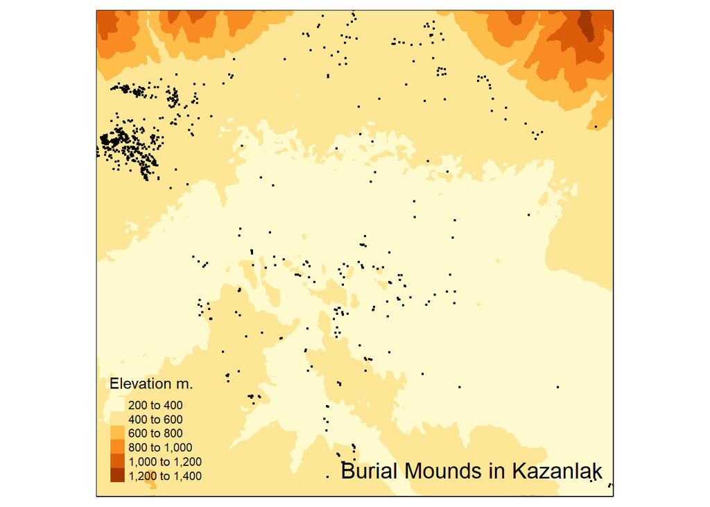

```r
#Cropping the elevation the bounding box of mounds
elevation <- crop(aster, st_bbox(mounds))

#Looking at the cropped map
tm_shape(elevation) +
    tm_raster(title = 'Elevation m.') +
tm_shape(mounds) +
    tm_dots() +
    tm_layout(
        'Burial Mounds in Kazanlak',
        title.position = c('right', 'bottom'),
        legend.position = c('left', 'bottom')
    )
```

```r
# Adding a new column to our mounds data containing the elevation for a given mound
mounds_elev <- raster::extract(elevation, mounds)
mounds$Elevation <- mounds_elev

# Compare elevation and condition using average elevation
condition_by_elev <- st_drop_geometry(mounds) %>%
    group_by(Condition) %>%
    drop_na() %>% # there are a few missing values for Elevation
    summarise(
        Elevation = mean(Elevation)
    )

#looking at our new column
print(condition_by_elev)
```

```
## # A tibble: 5 x 2
##   Condition Elevation
## *     <dbl>     <dbl>
## 1         1      439.
## 2         2      440.
## 3         3      446.
## 4         4      449.
## 5         5      419.
```

```r
#Comparing to looting (robbed)
robbed_by_elev <- st_drop_geometry(mounds) %>%
    group_by(Robbed) %>%
    drop_na() %>% # there are a few missing values for Elevation and Robbed
    summarise(
        Elevation = mean(Elevation)
    )
print(robbed_by_elev)
```

```
## # A tibble: 2 x 2
##   Robbed Elevation
## *  <dbl>     <dbl>
## 1      0      447.
## 2      1      437.
```

We can see that in terms of the mounds in worst condition, they seem to have a lower elevation than the rest. Then one could conclude that lower altitude mounds are in worse condition in general, but that would be faulty if we look at the other condition values. Value 4 the soars to having the highest altitude amongst all condition values, and from there they slowly descent. What this means i am not sure but it could indicate some correlation between elevation and condition. Perhaps if one added the landuse to the comparison, we could see that some landuse correlate with certain elevations, and the answer could lie there. That has been deemed outside the scope for this late sunday evening but could be interesting to look at.

In terms of looting, the robbed mounds seem to have a lower elevation than the ones that havent been robbed, but the difference isnt high and the result is inconclusive if you ask me. The logical explaination would be, that higher altitude mounds are harder to rob but for this to be descisive, more work is needed.

## Slope

So what about slope. Looking at the slope we have 2 elements. The slope itself and the aspect, which is the direction of the slope.

```r
#First we load in the slopes and the aspects using the terrain function.
slope_raster <- raster::terrain(elevation, opt='slope', unit='degrees', neighbors=4)
aspect_raster <- raster::terrain(elevation, opt='aspect', unit='degrees', neighbors=4)

#We then add the two to our mounds data
mounds <- mounds %>%
  mutate(slope = raster::extract(slope_raster, mounds)) %>%
  mutate(aspect = raster::extract(aspect_raster, mounds))


# Look at the correlation between slope and condition
condition_by_slope <- st_drop_geometry(mounds) %>%
    group_by(Condition) %>%
    drop_na() %>% # there are a few missing values for Slope
    summarise(
        Slope = mean(slope)
    )

print(condition_by_slope)
```

```
## # A tibble: 5 x 2
##   Condition Slope
## *     <dbl> <dbl>
## 1         1  3.79
## 2         2  3.41
## 3         3  4.51
## 4         4  3.86
## 5         5  3.72
```

```r
# Look at the correlation between aspect and condition
condition_by_aspect <- st_drop_geometry(mounds) %>%
    group_by(Condition) %>%
    drop_na() %>% # there are a few missing values for Slope
    summarise(
        Aspect = mean(aspect)
    )

print(condition_by_aspect)
```

```
## # A tibble: 5 x 2
##   Condition Aspect
## *     <dbl>  <dbl>
## 1         1   179.
## 2         2   161.
## 3         3   162.
## 4         4   159.
## 5         5   200.
```

In terms of the slope, there seems to be no real correlation between that and the condition of the mounds. For some reason, the mounds with a condition value of 3 seems to have a steeper slope than the rest and the reason for that seems unknown to me.

On the other hand, looking at the aspect we see that the mounds in worst condition are pointing towards south-south-west, while the rest points more towards south-south-east. The mounds in best condition points directly south. Now, what this exactly means i dont know but it would seem that the aspect has some sort of role to play. The aspects we’re looking at here are only mean-values, so it would be more interesting to look at individual mounds of the worst condition and see what direction they are pointing.